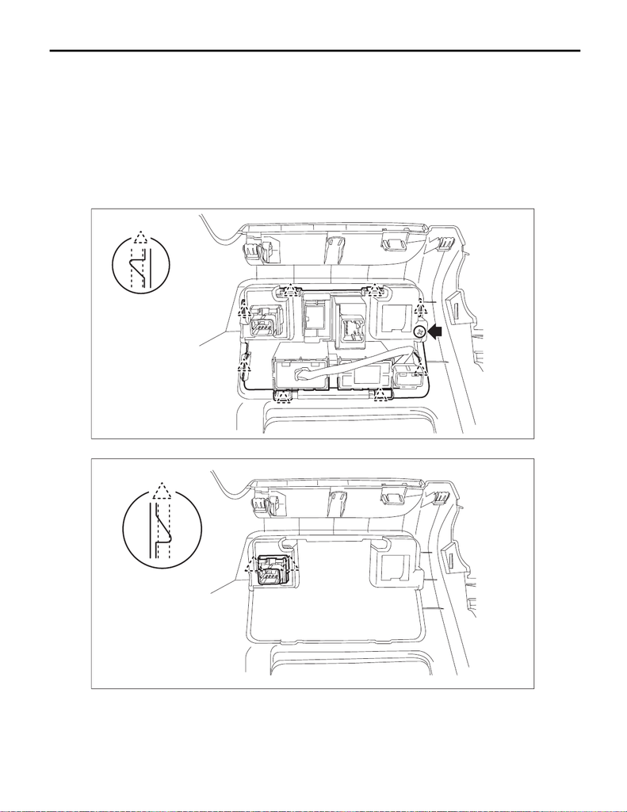

SL-47

Trunk Opener Switch

SECURITY AND LOCKS

14.Trunk Opener Switch

A: REMOVAL

NOTE:

For models other than STI model, disconnect the ground terminal from battery sensor.

3) Remove the trunk opener switch.

(1) Remove the screw, release the claws, and then remove the panel - switch.

(2) Release the claws and remove the trunk opener button.

SL-02864

VDC00967

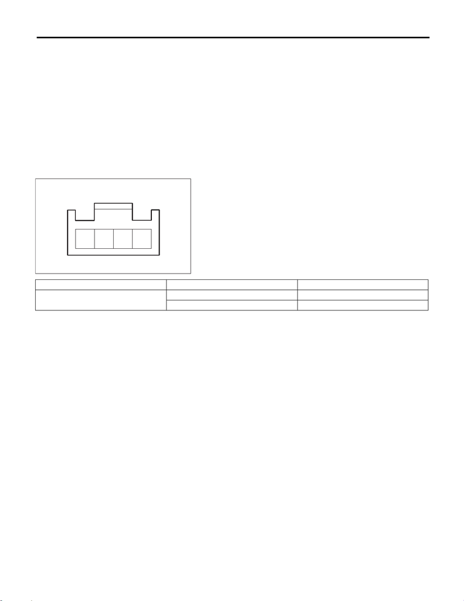

SL-48

Trunk Opener Switch

SECURITY AND LOCKS

B: INSTALLATION

1) Install the switch - trunk opener.

2) Install the panel - switch.

4) Connect the battery ground terminal. <Ref. to NT-5, BATTERY, NOTE, Note.>

NOTE:

For models other than STI model, connect the ground terminal to battery sensor.

C: INSPECTION

1) Measure the resistance between connector terminals.

Preparation tool:

Circuit tester

2) If the inspection result is not within the standard, replace the switch - trunk opener.

SL-02881

34 2 1

Terminal No. Inspection conditions Standard

2 — 3

Switch OFF 1 MΩ or more

Switch ON Less than 1 Ω